# Project Part C

Brett Karsten

2023-10-09

Produce summary statistics of “residual.sugar” and use its median to divide the data into two groups A and B. We want to test if “density” in Group A and Group B has the same population mean. Please answer the following questions.

Part 1

1. State the null hypothesis;
2. Use visualization tools to inspect the hypothesis. Do you think the hypothesis is right or not?
3. What test are you going to use?
4. What is the p-value?
5. What is your conclusion?
6. Does your conclusion imply that there is an association between “density” and “residual.sugar”?

```r
library(tidyverse)
library(stats4)
```

Load the data

```r
Red_Wine <- read_csv("/Users/brettkarsten/VS code/Applied Stat methods project/Wine Quality/winequality-red.csv")
```

Provide Summary Stats for Residual sugar

```r
summary(Red_Wine$`residual sugar`)
```

```
##    Min. 1st Qu.  Median    Mean 3rd Qu.    Max.
##   0.900   1.900   2.200   2.539   2.600  15.500
```

The median is `2.20`, lets split the data there.

```r
median_rs <- 2.20
```

```r
rs.group <- ifelse(Red_Wine$`residual sugar` < median_rs, 0, 1)
data.frame(Red_Wine$`residual sugar`, rs.group, Red_Wine$density)[1:10,]
```

```
##    Red_Wine..residual.sugar. rs.group Red_Wine.density
## 1                        1.9        0           0.9978
## 2                        2.6        1           0.9968
## 3                        2.3        1           0.9970
## 4                        1.9        0           0.9980
## 5                        1.9        0           0.9978
## 6                        1.8        0           0.9978
## 7                        1.6        0           0.9964
## 8                        1.2        0           0.9946
## 9                        2.0        0           0.9968
## 10                       6.1        1           0.9978
```

### Question 1 part A: State the null hypothesis;

The null hypothesis states that the population mean of the density variable in group A is no different than the population mean of the density variable within group B. In other words, they are equal. The alternative hypothesis states that there is a difference between the two means.

### Question 1 part B: Use visualization tools to inspect the hypothesis. Do you think the hypothesis is right or not?

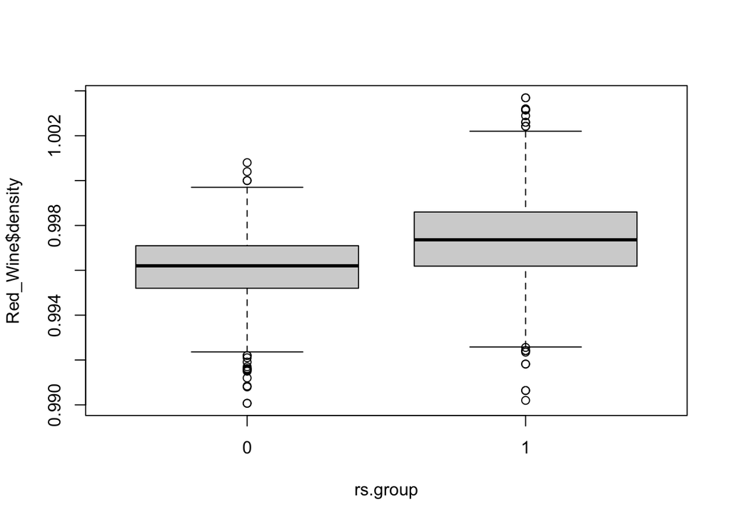

```r
boxplot(Red_Wine$density ~ rs.group)
```

### Question 1 part C: what test are you going to use?

Lets use a t-test to compare the two groups.

```r
t.test(Red_Wine$density ~ rs.group)
```

```
##
##  Welch Two Sample t-test
##
## data:  Red_Wine$density by rs.group
## t = -14.955, df = 1571.9, p-value < 2.2e-16
## alternative hypothesis: true difference in means between group 0 and group 1 is not equal to 0
## 95 percent confidence interval:
##  -0.001479826 -0.001136653
## sample estimates:
## mean in group 0 mean in group 1
##       0.9960537       0.9973619
```

### Question 1 part D: What is the p-value?

The p-value recorded is `2.2e-16`.

### Question 1 part E: What is your conclusion?

Based on this value, it is lower than the accepted value, alpha, which is universally accepted at around 0.05. Anything less than this value indicates there is a statistically significant difference between the two means. We are able to reject the null hypothesis.

### Question 1 part F: Does your conclusion imply that there is an association between “density” and

“residual.sugar”?

This may be truthful, as the p-value is lower than 0.05. Visually, we can also see a difference in means between the two groups. Further analysis may be needed. This compared the two means of density between the split data set based on the median of residual sugar. There may be an association between the residual sugar and density variable because the p-value from the t-test was below 0.05.

Part 2

Produce summary statistics of “residual.sugar” and use its 1st, 2nd, and 3rd quantiles to divide the data into four groups A, B, C, and D. We want to test if “density” in the four groups has the same population mean. Please answer the following questions.

1. State the null hypothesis;
2. Use visualization tools to inspect the hypothesis. Do you think the hypothesis is right or not?
3. What test are you going to use?
4. What is the p-value?
5. What is your conclusion?
6. Does your conclusion imply that there is an association between “density” and “residual.sugar”? Compare your result here with that in Question 1. Do you think increasing the number of groups help identify the association? Would you consider dividing the data into 10 groups so as to help the discovery of the association? Why?

Lets break the data up into 4 groups

```r
summary(Red_Wine$`residual sugar`)
```

```
##    Min. 1st Qu.  Median    Mean 3rd Qu.    Max.
##   0.900   1.900   2.200   2.539   2.600  15.500
```

As outlined in the notes…

```r
rs_4_groups <- NULL

for (i in 1:1599) {  # sample size
  if (Red_Wine$`residual sugar`[i] <= 1.9) rs_4_groups[i] <- 1
      else if (Red_Wine$`residual sugar`[i] <= 2.20) rs_4_groups[i] <- 2
        else if(Red_Wine$`residual sugar`[i] <= 2.60) rs_4_groups[i] <- 3
          else rs_4_groups[i] <- 4
}
```

```r
table(rs_4_groups)
```

```
## rs_4_groups
##   1   2   3   4
## 464 419 361 355
```

### Question 2 part A: a. State the null hypothesis;

The null hypothesis states that the population mean within the density variable between the four groups created are equal to each other and that there is no difference between them. The alternate hypothesis states that the difference is significant and there is, in fact, a difference between the means.

### Question 2 part B: Use visualization tools to inspect the hypothesis. Do you think the hypothesis is right or not?

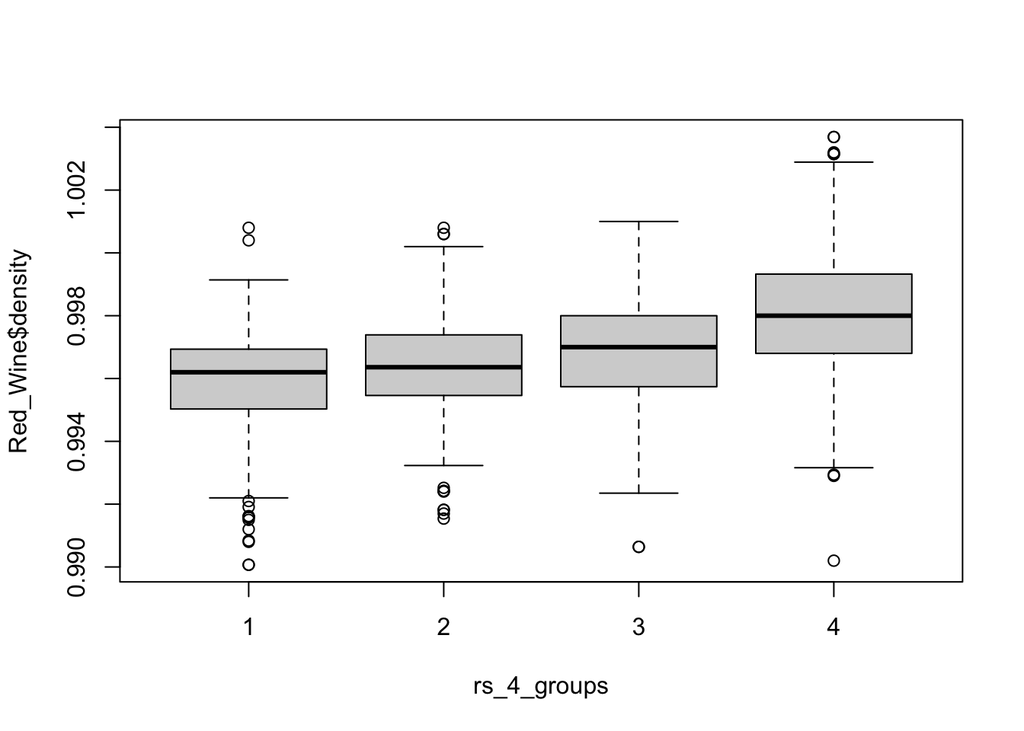

```r
boxplot(Red_Wine$density ~ rs_4_groups)
```

There appears to be a difference between the means of the density values for each of the 4 groups created from residual sugar’s 1st, 2nd, 3rd quartiles.

### Question 2 part C:What test are you going to use?

For multiple groups, we will use an ANOVA test the means between multiple groups.

```r
summary(aov(Red_Wine$density ~ rs_4_groups))
```

```
##               Df   Sum Sq   Mean Sq F value Pr(>F)
## rs_4_groups    1 0.000950 0.0009503     320 <2e-16 ***
## Residuals   1597 0.004742 0.0000030
## ---
## Signif. codes:  0 '***' 0.001 '**' 0.01 '*' 0.05 '.' 0.1 ' ' 1
```

### Question 2 part D: What is the p-value?

The p-value from the ANOVA test is `2e-16`. This is slightly lower than the previous p-value, but the difference is negligible since it still is < alpha (0.05).

### Question 2 part E: What is your conclusion?

Since the p-value for the ANOVA test is lower than alpha, it would suggest that there is a difference between the means for the density variable between each of the 4 groups split up by residual sugar’s quartiles. We can reject the null hypothesis.

### Question 2 part F: Does your conclusion imply that there is an association between “density” and

“residual.sugar”? Compare your result here with that in Question 1. Do you think increasing the number of groups help identify the association? Would you consider dividing the data into 10 groups so as to help the discovery of the association? Why?

Based on the findings above, it suggests or implies that there is an association between the density and residual sugar variables. The results from question 1 are very similar with the respective p-values. There was a slight difference in p-values which may suggest that splitting the data up into multiple groups ensures a more reliable answer. Potentially, this could extract falsehoods from conclusions with less groups, but in this case, it just yields a slightly different p-value that still allows us to reject the null hypothesis with confidence and say there is a significant difference between the 4 group means. Splitting the data up into 10 groups may be unnecessary, however, it also may demonstrate the validity of splitting the data to show correlations between variables. For learning purposes, it may be worth showing.

Part 3

Create a 2 by 4 contingency table using the categories A, B, C, D of “residual.sugar” and the binary variable “excellent” you created in Part B. Note that you have two factors: the categorical levels of “residual.sugar” (A, B, C and D) and an indicator of excellent wines (yes or no).

```r
Red_Wine$excellent <- as.numeric(Red_Wine$quality >= 7)
```

0 indicates a wine with a quality rating less than 7 and 1 indicates a wine quality greater than or equal to 7

```r
ctable <- table(Red_Wine$excellent, rs_4_groups)
ctable
```

```
##    rs_4_groups
##       1   2   3   4
##   0 411 367 308 296
##   1  53  52  53  59
```

### Question 3 part A: Use the Chi-square test to test if these two factors are correlated or not;

```r
chisq_results <- chisq.test(ctable, simulate.p.value = T)
chisq_results
```

```
##
##  Pearson's Chi-squared test with simulated p-value (based on 2000
##  replicates)
##
## data:  ctable
## X-squared = 5.5, df = NA, p-value = 0.1434
```

### Question 3 part B: Use the permutation test to do the same and compare the result to that in (a);

```r
chisq_result_stat <- chisq_results$statistic

permutation_chisq <- numeric(1000)

for (i in 1:1000) {
  random_excellent <- sample(Red_Wine$excellent)
  random_table <- table(random_excellent, rs_4_groups) # making a new ctable for reach random sample
  permutation_chisq[i] <- chisq.test(random_table)$statistic # chi sq value for each random table
}
p_value_permutation_test <- sum(permutation_chisq >= chisq_result_stat) / 1000 # number of replications

print(p_value_permutation_test)
```

```
## [1] 0.143
```

The p-value for the chi squared test is 0.1434283 and the p-value for the permutation test is 0.143. The values are very close to one another. This suggests that both methods are reliable.

### Question 3 part C:Can you conclude that “residual.sugar” is a significant factor contributing to the excellence of wine? Why?

Based on the p-values provided, they are both above the accepted alpha value of 0.05. This means that we are not able to conclude one variable contains a relationship with the other. Residual sugar, based on statistics, does not seem to be a significant factor contributing to the excellence rating of wine. The null hypothesis would state that there is no difference between the two variables and that the residual sugar does not affect the excellence of a wine. Because the p-values for both the chi squared and permutation test are greater than 0.05, we accept the null hypothesis in this case rather than reject it.